# Analiza statystyczna danych dialogowych z serialu Gra o tron

Mikołaj Wielgos

21 stycznia 2022 r.

# Wstęp

Projekt na przedmiot Rachunek prawdopodobieństwa i statystyka 2021/22.

Obejmuje on analizę statystyczną wszystkich kwestii bohaterów w serialu *[Gra o tron](https://en.wikipedia.org/wiki/Game_of_Thrones)*

Źródło danych opracowywanych *www.kaggle.com/gopinath15/gameofthrones*

# Początek

Importuję potrzebne pakiety

```r
library(DBI)
library(dbplot)
library(dplyr)
library(ggplot2)
```

Łączę się z bazą danych “got-dataset.db”

```r
con <- dbConnect(drv=RSQLite::SQLite(), dbname="data/got-dataset.db")
```

Sprawdzam jakie tabele zawiera baza danych

```r
dbListTables(con)
```

[output not shown]

# Czyszczenie danych

## Puste pola ‘Speaker’

Interesują nas kwestie wypowiedziane tylko przez postacie w serialu (wpis Speaker nie może być pusty). Przykładowy błędny wiersz

```r
query <- "
SELECT substr(Text,1,20)||'...'as 'Text',
Speaker,
Episode,
Season
FROM [got-dialogues]
WHERE Speaker=''
LIMIT 1"
dbGetQuery(con, query)
```

| Text | Speaker | Episode | Season |
| --- | --- | --- | --- |
| [First scene opens w... |  | e1-Winter is Coming | season-01 |

Kwerenda usuwająca wiersze

```r
query <- "
DELETE
FROM [got-dialogues]
WHERE SPEAKER = ''"
res <- dbSendStatement(con, query)
```

Sprawdzam na ile wierszy miała wpływa kwerenda

```r
dbGetRowsAffected(res)
```

```
[1] 8356
```

```r
dbClearResult(res)
```

## Kwestie postaci w tle

Usuwamy kwestie postaci w tle, przedstawianych jako np. Woman #4 Przykładowy błędny wiersz

```r
query <- "
SELECT substr(Text,1,20)||'...'as 'Text',
Speaker,
Episode,
Season
FROM [got-dialogues]
WHERE Speaker LIKE '%#%'
LIMIT 1"
dbGetQuery(con, query)
```

| Text | Speaker | Episode | Season |
| --- | --- | --- | --- |
| You earned that, S... | Night’s Watcher #1 | e9-Baelor | season-01 |

Kwerenda usuwająca wiersze

```r
query <- "
DELETE
FROM [got-dialogues]
WHERE Speaker LIKE '%#%'"
res <- dbSendStatement(con, query)
```

Sprawdzam na ile wierszy miała wpływa kwerenda

```r
dbGetRowsAffected(res)
```

```
[1] 206
```

```r
dbClearResult(res)
```

## Wspólne kwestie

Usuwamy wspólne kwestie, dotyczy pozycji typu ‘ALL TOGETHER’, ‘ALL THREE’, ‘ALL AT THE BACK’ Przykładowy błędny wiersz

```r
query <- "
SELECT substr(Text,1,20)||'...'as 'Text',
Speaker,
Episode,
Season
FROM [got-dialogues]
WHERE Speaker LIKE '%ALL%'
LIMIT 1"
dbGetQuery(con, query)
```

| Text | Speaker | Episode | Season |
| --- | --- | --- | --- |
| (chanting) The Ki... | All | e10-Fire and Blood | season-01 |

Kwerenda usuwająca wiersz

```r
query <- "
DELETE
FROM [got-dialogues]
WHERE Speaker LIKE '%ALL%'"
res <- dbSendStatement(con, query)
```

Sprawdzam na ile wierszy miała wpływa kwerenda

```r
dbGetRowsAffected(res)
```

```
[1] 177
```

```r
dbClearResult(res)
```

## Nieznaczące wypowiedzi

Usuwamy pojedyncze, mało znaczące wypowiedzi

Przykładowy błędny wiersz

```r
query <- "
SELECT substr(Text,1,20)||'...' as 'Text',
Speaker,
Episode,
Season
FROM [got-dialogues]
GROUP BY Speaker
HAVING COUNT(*)=1
LIMIT 1"
dbGetQuery(con, query)
```

| Text | Speaker | Episode | Season |
| --- | --- | --- | --- |
| come to King's Land... | "Robb, I write to you with a heavy heart. Our good king Robert is dead, killed from wounds he took in a boar hunt. Father has been charged with treason. He conspired with Robert's brothers against my … | e5 | season-07 |

Kwerenda usuwająca wiersze

```r
query <- "
DELETE
FROM [got-dialogues]
where Speaker in (SELECT Speaker
FROM [got-dialogues]
GROUP BY Speaker
HAVING COUNT(*)=1)"
res <- dbSendStatement(con, query)
```

Sprawdzam na ile wierszy miała wpływa kwerenda

```r
dbGetRowsAffected(res)
```

```
[1] 363
```

```r
dbClearResult(res)
```

## Ujednolicenie pola ‘Speaker’

W bazie danych pojawiają się wpisy typu Speaker=‘Roose’ oraz Speaker=‘ROOSE’, dlatego trzymamy się jednej wersji (WIELKIE LITERY)

```r
query <- "
UPDATE [got-dialogues]
SET Speaker = UPPER(Speaker)"
res <- dbSendStatement(con, query)
dbGetRowsAffected(res)
```

```
[1] 24096
```

```r
dbClearResult(res)
```

## Podsumowanie i przykładowe dane

Po przeczyszczeniu przykładowe wpisy w bazie wyglądają następująco (kolumna ‘Text’ ograniczona do 20 znaków, by zwiększyć czytelność)

```r
query <- "
SELECT substr(Text,1,20)||'...' as 'Text',
Speaker,
Episode,
Season
FROM [got-dialogues]
LIMIT 5"
dbGetQuery(con, query)
```

| Text | Speaker | Episode | Season |
| --- | --- | --- | --- |
| What d’you expect? ... | WAYMAR ROYCE | e1-Winter is Coming | season-01 |
| I’ve never seen wil... | WILL | e1-Winter is Coming | season-01 |
| How close did you g... | WAYMAR ROYCE | e1-Winter is Coming | season-01 |
| Close as any man wo... | WILL | e1-Winter is Coming | season-01 |
| We should head back... | GARED | e1-Winter is Coming | season-01 |

# Analiza eksploracyjna

## Ilość dialogów w poszczególnych sezonach

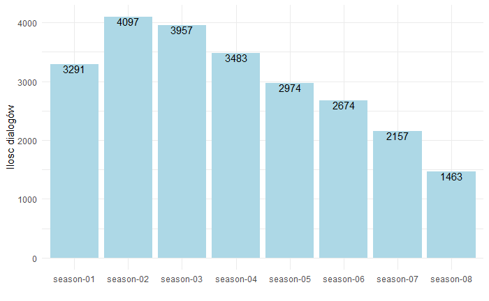

```r
df <- dbGetQuery(con,"
SELECT Season,
COUNT(*)
FROM [got-dialogues]
GROUP BY Season")
ggplot(data=df, aes(x = df[,1], y=df[,2])) +
  geom_bar(stat = "identity", fill="lightblue") +
  geom_text(aes(label = df[,2]), vjust = 1) +
  labs(x="", y="Ilość dialogów") +
  theme_minimal()
```

Wskaźniki:

```r
summary(df[,2])
```

```
   Min. 1st Qu.  Median    Mean 3rd Qu.    Max.
   1463    2545    3132    3012    3602    4097
```

```r
var(df[,2])
```

```
[1] 802292.3
```

```r
sd(df[,2])
```

```
[1] 895.7077
```

## Ilość dialogów poszczególnych bohaterów (wszystkie sezony, 10 największych)

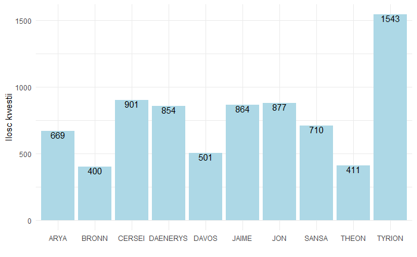

```r
df <- dbGetQuery(con,"
SELECT Speaker,
COUNT(*)
FROM [got-dialogues]
GROUP BY Speaker
ORDER BY 2 DESC
LIMIT 10")
ggplot(data=df, aes(x = df[,1], y=df[,2])) +
  geom_bar(stat = "identity", fill="lightblue") +
  geom_text(aes(label = df[,2]), vjust = 1) +
  labs(x="", y="Ilość kwestii") +
  theme_minimal()
```

By policzyć wskaźniki wszystkich bohaterów, ponownie wybieram dane (tym razem bez limitu)

```r
df <- dbGetQuery(con,"
SELECT Speaker,
COUNT(*)
FROM [got-dialogues]
GROUP BY Speaker")
```

Wskaźniki:

```r
summary(df[,2])
```

```
   Min. 1st Qu.  Median    Mean 3rd Qu.    Max.
    2.0     4.0    10.0    50.1    34.0  1543.0
```

```r
var(df[,2])
```

```
[1] 17203.06
```

```r
sd(df[,2])
```

```
[1] 131.1604
```

## Długości kwestii (znaki) w poszczególnych sezonach

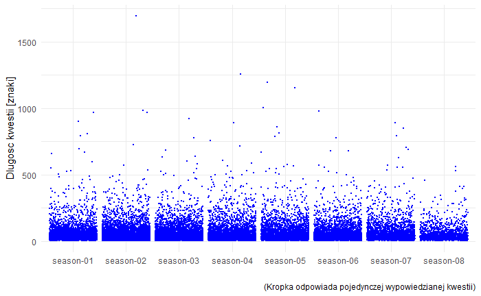

```r
df <- dbGetQuery(con,"
SELECT Season,
length(Text)
FROM [got-dialogues]")
ggplot(data=df, aes(x = df[,1], y=df[,2])) +
  geom_jitter(size = 0.1, position = position_jitter(0.45), color="blue") +
  labs(x="",
       y="Długość kwestii [znaki]",
       caption="(Kropka odpowiada pojedynczej wypowiedzianej kwestii)") +
  theme_minimal()
```

Wskaźniki:

```r
summary(df[,2])
```

```
   Min. 1st Qu.  Median    Mean 3rd Qu.    Max.
   3.00   21.00   39.00   61.71   76.00 1693.00
```

```r
var(df[,2])
```

```
[1] 5249.661
```

```r
sd(df[,2])
```

```
[1] 72.45454
```

## Najczęstszy mówca w danym sezonie

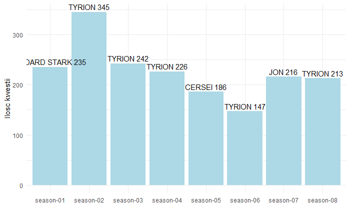

```r
df <- dbGetQuery(con,"
SELECT Season,
(SELECT Speaker
FROM [got-dialogues] as inner
WHERE outer.Season=inner.Season
GROUP BY Speaker
ORDER BY COUNT(*)
DESC LIMIT 1 ) as TopSpeaker,
(SELECT COUNT(*)
FROM [got-dialogues] as inner
WHERE outer.Season=inner.Season
GROUP BY Speaker
ORDER BY COUNT(*) DESC
LIMIT 1) as Amount
FROM (SELECT DISTINCT Season FROM [got-dialogues]) as outer")

ggplot(data=df, aes(x = df[,1], y=df[,3])) +
  geom_bar(stat = "identity", fill="lightblue") +
  geom_text(aes(label = paste(df[,2],df[,3])), vjust = -0.4) +
  labs(x="", y="Ilość kwestii") +
  theme_minimal()
```

Wskaźniki:

```r
summary(df[,3])
```

```
   Min. 1st Qu.  Median    Mean 3rd Qu.    Max.
  147.0   206.2   221.0   226.2   236.8   345.0
```

```r
var(df[,3])
```

```
[1] 3229.643
```

```r
sd(df[,3])
```

```
[1] 56.82995
```

# Regresja liniowa

## Punkty i wartości na których oprę regresję

Do regresji nie wliczam sezonu 1, w którym wartości dialogów nie układają się w stosunku do reszty. Punkty na których obliczę wyglądają następująco:

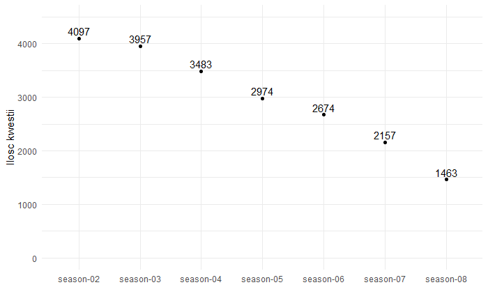

```r
df <- dbGetQuery(con,"
SELECT Season,
COUNT(*)
FROM [got-dialogues]
WHERE Season !='season-01'
GROUP BY Season")
ggplot(data=df, aes(x = df[,1], y=df[,2])) +
  geom_point(stat = "identity", fill="lightblue") +
  geom_text(aes(label = df[,2]), vjust = -0.4) +
  labs(x="", y="") +
  scale_y_continuous(name="Ilość kwestii", limits=c(0, 4500))+
  theme_minimal()
```

## Model regresji liniowej

Tworzę model

```r
df <- dbGetQuery(con,"
SELECT substr(Season,9,10),
COUNT(*)
FROM [got-dialogues]
WHERE Season !='season-01'
GROUP BY Season")
df2 <- data.frame(x = as.numeric(df[,1]), y=df[,2])
model_lm <- lm(y~x, data=df2)
df_lm <- data.frame(x = 2:12)
```

Informacje o modelu

```r
summary(model_lm)
```

```
Call:
lm(formula = y ~ x, data = df2)

Residuals:
       1        2        3        4        5        6        7
-194.179  105.500   71.179    1.857  141.536   64.214 -190.107

Coefficients:
            Estimate Std. Error t value Pr(>|t|)
(Intercept)  5170.54     153.81   33.62 4.38e-07 ***
x            -439.68      28.56  -15.39 2.10e-05 ***
---
Signif. codes:  0 ‘***’ 0.001 ‘**’ 0.01 ‘*’ 0.05 ‘.’ 0.1 ‘ ’ 1

Residual standard error: 151.1 on 5 degrees of freedom
Multiple R-squared:  0.9793,    Adjusted R-squared:  0.9752
F-statistic:   237 on 1 and 5 DF,  p-value: 2.099e-05
```

## Wykres regresji liniowej

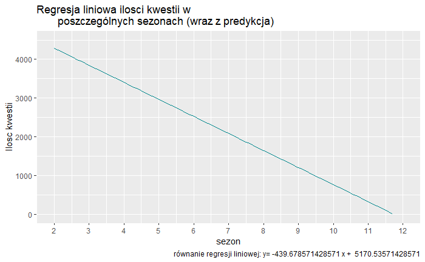

```r
ggplot(df_lm, aes(x)) +
  stat_function(
    fun=function(x) coefficients(model_lm)[1]+x*(coefficients(model_lm)[2]),
    color='turquoise4') +
  scale_x_continuous(
    "sezon",
    labels = as.character(df_lm$x),
    breaks = df_lm$x,
    limits=c(2,12))+
  scale_y_continuous(name="Ilość kwestii", limits=c(0, 4500)) +
  labs(title="Regresja liniowa ilości kwestii w
       poszczególnych sezonach (wraz z predykcją)",
       caption=paste("równanie regresji liniowej: y=",
                     coefficients(model_lm)[2],"x + ",
                     coefficients(model_lm)[1]))
```

Obliczam punkt przecięcia z osią OX.

```r
point <- -1*(coefficients(model_lm)[1])/(coefficients(model_lm)[2])
print(point)
```

```
(Intercept)
   11.75981
```

Czy w sezonie 12 już nikt się nie wypowie? :D

# Zakończenie

Kończę pracę z bazą

```r
dbDisconnect(con)
unlink("data/got-dataset.db")
```

# Podsumowanie

Choć wybrałem dane proste, bo przecież to tylko kwestie bohaterów, można było dowiedzieć się z nich całkiem sporo. Wniosek po krótce jest taki, że od sezonu 2 Gry o tron, bohaterowie co raz bardziej nie lubią się wypowiadać. Dodatkowo w sezonie 2 padł rekord pod względem długości kwestii (ponad 1500 znaków w pojedynczej wypowiedzi).